# Bike Sharing in San Franscisco Bay Area Exploration

## Preliminary Wrangling

```python
# import all packages and set plots to be embedded inline
import numpy as np
import pandas as pd
import matplotlib.pyplot as plt
import seaborn as sb
from datetime import date
from datetime import datetime
import calendar

%matplotlib inline
```

```python
# load the dataset and outline higlevel overview

def read_csv_file(filename):
    """function to read csv files"""
    data = pd.read_csv(filename)
    data

    return data
```

```python
rides = read_csv_file('201902-fordgobike-tripdata.csv')
rides
```

|  | duration_sec | start_time | end_time | start_station_id | start_station_name | start_station_latitude | start_station_longitude | end_station_id | end_station_name | end_station_latitude | end_station_longitude | bike_id | user_type | member_birth_year | member_gender | bike_share_for_all_trip |
| --- | --- | --- | --- | --- | --- | --- | --- | --- | --- | --- | --- | --- | --- | --- | --- | --- |
| 0 | 52185 | 2019-02-28 17:32:10.1450 | 2019-03-01 08:01:55.9750 | 21.0 | Montgomery St BART Station (Market St at 2nd St) | 37.789625 | -122.400811 | 13.0 | Commercial St at Montgomery St | 37.794231 | -122.402923 | 4902 | Customer | 1984.0 | Male | No |
| 1 | 42521 | 2019-02-28 18:53:21.7890 | 2019-03-01 06:42:03.0560 | 23.0 | The Embarcadero at Steuart St | 37.791464 | -122.391034 | 81.0 | Berry St at 4th St | 37.775880 | -122.393170 | 2535 | Customer | NaN | NaN | No |
| 2 | 61854 | 2019-02-28 12:13:13.2180 | 2019-03-01 05:24:08.1460 | 86.0 | Market St at Dolores St | 37.769305 | -122.426826 | 3.0 | Powell St BART Station (Market St at 4th St) | 37.786375 | -122.404904 | 5905 | Customer | 1972.0 | Male | No |
| 3 | 36490 | 2019-02-28 17:54:26.0100 | 2019-03-01 04:02:36.8420 | 375.0 | Grove St at Masonic Ave | 37.774836 | -122.446546 | 70.0 | Central Ave at Fell St | 37.773311 | -122.444293 | 6638 | Subscriber | 1989.0 | Other | No |
| 4 | 1585 | 2019-02-28 23:54:18.5490 | 2019-03-01 00:20:44.0740 | 7.0 | Frank H Ogawa Plaza | 37.804562 | -122.271738 | 222.0 | 10th Ave at E 15th St | 37.792714 | -122.248780 | 4898 | Subscriber | 1974.0 | Male | Yes |
| 5 | 1793 | 2019-02-28 23:49:58.6320 | 2019-03-01 00:19:51.7600 | 93.0 | 4th St at Mission Bay Blvd S | 37.770407 | -122.391198 | 323.0 | Broadway at Kearny | 37.798014 | -122.405950 | 5200 | Subscriber | 1959.0 | Male | No |
| 6 | 1147 | 2019-02-28 23:55:35.1040 | 2019-03-01 00:14:42.5880 | 300.0 | Palm St at Willow St | 37.317298 | -121.884995 | 312.0 | San Jose Diridon Station | 37.329732 | -121.901782 | 3803 | Subscriber | 1983.0 | Female | No |
| 7 | 1615 | 2019-02-28 23:41:06.7660 | 2019-03-01 00:08:02.7560 | 10.0 | Washington St at Kearny St | 37.795393 | -122.404770 | 127.0 | Valencia St at 21st St | 37.756708 | -122.421025 | 6329 | Subscriber | 1989.0 | Male | No |
| 8 | 1570 | 2019-02-28 23:41:48.7900 | 2019-03-01 00:07:59.7150 | 10.0 | Washington St at Kearny St | 37.795393 | -122.404770 | 127.0 | Valencia St at 21st St | 37.756708 | -122.421025 | 6548 | Subscriber | 1988.0 | Other | No |
| 9 | 1049 | 2019-02-28 23:49:47.6990 | 2019-03-01 00:07:17.0250 | 19.0 | Post St at Kearny St | 37.788975 | -122.403452 | 121.0 | Mission Playground | 37.759210 | -122.421339 | 6488 | Subscriber | 1992.0 | Male | No |
| 10 | 458 | 2019-02-28 23:57:57.2110 | 2019-03-01 00:05:35.4350 | 370.0 | Jones St at Post St | 37.787327 | -122.413278 | 43.0 | San Francisco Public Library (Grove St at Hyde... | 37.778768 | -122.415929 | 5318 | Subscriber | 1996.0 | Female | Yes |
| 11 | 506 | 2019-02-28 23:56:55.5400 | 2019-03-01 00:05:21.7330 | 44.0 | Civic Center/UN Plaza BART Station (Market St ... | 37.781074 | -122.411738 | 343.0 | Bryant St at 2nd St | 37.783172 | -122.393572 | 5848 | Subscriber | 1993.0 | Male | No |
| 12 | 1176 | 2019-02-28 23:45:12.6510 | 2019-03-01 00:04:49.1840 | 127.0 | Valencia St at 21st St | 37.756708 | -122.421025 | 323.0 | Broadway at Kearny | 37.798014 | -122.405950 | 5328 | Customer | 1990.0 | Male | No |
| 13 | 915 | 2019-02-28 23:49:06.0620 | 2019-03-01 00:04:21.8670 | 252.0 | Channing Way at Shattuck Ave | 37.865847 | -122.267443 | 244.0 | Shattuck Ave at Hearst Ave | 37.873676 | -122.268487 | 5101 | Subscriber | NaN | NaN | No |
| 14 | 395 | 2019-02-28 23:56:26.8480 | 2019-03-01 00:03:01.9470 | 243.0 | Bancroft Way at College Ave | 37.869360 | -122.254337 | 252.0 | Channing Way at Shattuck Ave | 37.865847 | -122.267443 | 4786 | Subscriber | 1988.0 | Male | No |
| 15 | 208 | 2019-02-28 23:59:18.5480 | 2019-03-01 00:02:47.2280 | 349.0 | Howard St at Mary St | 37.781010 | -122.405666 | 60.0 | 8th St at Ringold St | 37.774520 | -122.409449 | 6361 | Subscriber | 1993.0 | Male | Yes |
| 16 | 548 | 2019-02-28 23:50:41.6070 | 2019-02-28 23:59:49.9530 | 131.0 | 22nd St at Dolores St | 37.755000 | -122.425728 | 71.0 | Broderick St at Oak St | 37.773063 | -122.439078 | 6572 | Subscriber | 1981.0 | Male | No |
| 17 | 674 | 2019-02-28 23:48:25.0950 | 2019-02-28 23:59:40.0920 | 74.0 | Laguna St at Hayes St | 37.776435 | -122.426244 | 336.0 | Potrero Ave and Mariposa St | 37.763281 | -122.407377 | 5343 | Subscriber | 1975.0 | Male | No |
| 18 | 557 | 2019-02-28 23:49:01.8510 | 2019-02-28 23:58:19.8090 | 321.0 | 5th St at Folsom | 37.780146 | -122.403071 | 75.0 | Market St at Franklin St | 37.773793 | -122.421239 | 5854 | Subscriber | 1990.0 | Male | No |
| 19 | 874 | 2019-02-28 23:43:05.1830 | 2019-02-28 23:57:39.7960 | 180.0 | Telegraph Ave at 23rd St | 37.812678 | -122.268773 | 180.0 | Telegraph Ave at 23rd St | 37.812678 | -122.268773 | 5629 | Customer | 1978.0 | Male | No |
| 20 | 417 | 2019-02-28 23:50:38.2390 | 2019-02-28 23:57:35.8520 | 72.0 | Page St at Scott St | 37.772406 | -122.435650 | 107.0 | 17th St at Dolores St | 37.763015 | -122.426497 | 4999 | Subscriber | 1983.0 | Male | No |
| 21 | 414 | 2019-02-28 23:50:26.8790 | 2019-02-28 23:57:21.1300 | 163.0 | Lake Merritt BART Station | 37.797320 | -122.265320 | 221.0 | 6th Ave at E 12th St (Temporary Location) | 37.794396 | -122.253842 | 6007 | Subscriber | 1984.0 | Male | Yes |
| 22 | 743 | 2019-02-28 23:44:56.4390 | 2019-02-28 23:57:20.2120 | 370.0 | Jones St at Post St | 37.787327 | -122.413278 | 52.0 | McAllister St at Baker St | 37.777416 | -122.441838 | 5479 | Subscriber | 1991.0 | Female | No |
| 23 | 367 | 2019-02-28 23:51:06.0140 | 2019-02-28 23:57:13.3120 | 243.0 | Bancroft Way at College Ave | 37.869360 | -122.254337 | 269.0 | Telegraph Ave at Carleton St | 37.862320 | -122.258801 | 1804 | Subscriber | 1997.0 | Female | No |
| 24 | 252 | 2019-02-28 23:52:51.1640 | 2019-02-28 23:57:03.9760 | 190.0 | West St at 40th St | 37.830223 | -122.270950 | 189.0 | Genoa St at 55th St | 37.839649 | -122.271756 | 5678 | Subscriber | 1975.0 | Male | No |
| 25 | 360 | 2019-02-28 23:50:31.4310 | 2019-02-28 23:56:31.8910 | 163.0 | Lake Merritt BART Station | 37.797320 | -122.265320 | 196.0 | Grand Ave at Perkins St | 37.808894 | -122.256460 | 6240 | Subscriber | 1986.0 | Male | No |
| 26 | 385 | 2019-02-28 23:49:24.3990 | 2019-02-28 23:55:50.2840 | 6.0 | The Embarcadero at Sansome St | 37.804770 | -122.403234 | 15.0 | San Francisco Ferry Building (Harry Bridges Pl... | 37.795392 | -122.394203 | 6531 | Customer | 2000.0 | Male | No |
| 27 | 408 | 2019-02-28 23:48:08.2820 | 2019-02-28 23:54:56.9300 | 78.0 | Folsom St at 9th St | 37.773717 | -122.411647 | 78.0 | Folsom St at 9th St | 37.773717 | -122.411647 | 5410 | Subscriber | 1982.0 | Male | No |
| 28 | 650 | 2019-02-28 23:43:27.5030 | 2019-02-28 23:54:18.4510 | 258.0 | University Ave at Oxford St | 37.872355 | -122.266447 | 263.0 | Channing Way at San Pablo Ave | 37.862827 | -122.290230 | 4784 | Customer | NaN | NaN | No |
| 29 | 629 | 2019-02-28 23:43:48.6580 | 2019-02-28 23:54:18.2540 | 258.0 | University Ave at Oxford St | 37.872355 | -122.266447 | 263.0 | Channing Way at San Pablo Ave | 37.862827 | -122.290230 | 363 | Subscriber | 1995.0 | Male | No |
| ... | ... | ... | ... | ... | ... | ... | ... | ... | ... | ... | ... | ... | ... | ... | ... | ... |
| 183382 | 961 | 2019-02-01 00:38:29.9040 | 2019-02-01 00:54:31.7320 | 95.0 | Sanchez St at 15th St | 37.766219 | -122.431060 | 324.0 | Union Square (Powell St at Post St) | 37.788300 | -122.408531 | 1565 | Subscriber | 1988.0 | Male | No |
| 183383 | 434 | 2019-02-01 00:47:11.6530 | 2019-02-01 00:54:26.3050 | 274.0 | Oregon St at Adeline St | 37.857567 | -122.267558 | 244.0 | Shattuck Ave at Hearst Ave | 37.873676 | -122.268487 | 4541 | Customer | 1997.0 | Male | No |
| 183384 | 184 | 2019-02-01 00:50:41.5790 | 2019-02-01 00:53:46.1240 | 316.0 | San Salvador St at 1st St | 37.330165 | -121.885831 | 298.0 | Oak St at 1st St | 37.322125 | -121.881090 | 4044 | Subscriber | 1991.0 | Male | No |
| 183385 | 400 | 2019-02-01 00:46:47.2760 | 2019-02-01 00:53:27.5960 | 220.0 | San Pablo Ave at MLK Jr Way | 37.811351 | -122.273422 | 337.0 | Webster St at 19th St | 37.806970 | -122.266588 | 3487 | Subscriber | 1945.0 | Male | Yes |
| 183386 | 425 | 2019-02-01 00:42:20.4720 | 2019-02-01 00:49:25.5150 | 239.0 | Bancroft Way at Telegraph Ave | 37.868813 | -122.258764 | 245.0 | Downtown Berkeley BART | 37.870139 | -122.268422 | 1377 | Subscriber | 1998.0 | Male | Yes |
| 183387 | 598 | 2019-02-01 00:39:12.6840 | 2019-02-01 00:49:10.7910 | 239.0 | Bancroft Way at Telegraph Ave | 37.868813 | -122.258764 | 245.0 | Downtown Berkeley BART | 37.870139 | -122.268422 | 2055 | Subscriber | 1999.0 | Male | Yes |
| 183388 | 490 | 2019-02-01 00:39:53.1120 | 2019-02-01 00:48:03.3380 | 61.0 | Howard St at 8th St | 37.776513 | -122.411306 | 81.0 | Berry St at 4th St | 37.775880 | -122.393170 | 5411 | Subscriber | 1927.0 | Male | No |
| 183389 | 184 | 2019-02-01 00:43:56.5560 | 2019-02-01 00:47:01.0090 | 66.0 | 3rd St at Townsend St | 37.778742 | -122.392741 | 47.0 | 4th St at Harrison St | 37.780955 | -122.399749 | 4960 | Subscriber | 1985.0 | Other | No |
| 183390 | 232 | 2019-02-01 00:40:00.0350 | 2019-02-01 00:43:52.8800 | 239.0 | Bancroft Way at Telegraph Ave | 37.868813 | -122.258764 | 266.0 | Parker St at Fulton St | 37.862464 | -122.264791 | 3756 | Subscriber | 1999.0 | Male | No |
| 183391 | 269 | 2019-02-01 00:37:47.5270 | 2019-02-01 00:42:17.0600 | 119.0 | 18th St at Noe St | 37.761047 | -122.432642 | 85.0 | Church St at Duboce Ave | 37.770083 | -122.429156 | 5540 | Subscriber | 1980.0 | Male | Yes |
| 183392 | 1289 | 2019-02-01 00:19:45.6410 | 2019-02-01 00:41:15.5580 | 8.0 | The Embarcadero at Vallejo St | 37.799953 | -122.398525 | 350.0 | 8th St at Brannan St | 37.771431 | -122.405787 | 3506 | Subscriber | 1993.0 | Male | No |
| 183393 | 155 | 2019-02-01 00:37:26.3680 | 2019-02-01 00:40:01.5760 | 116.0 | Mississippi St at 17th St | 37.764802 | -122.394771 | 93.0 | 4th St at Mission Bay Blvd S | 37.770407 | -122.391198 | 5406 | Subscriber | 1985.0 | Male | No |
| 183394 | 720 | 2019-02-01 00:27:33.8340 | 2019-02-01 00:39:34.2330 | 26.0 | 1st St at Folsom St | 37.787290 | -122.394380 | 96.0 | Dolores St at 15th St | 37.766210 | -122.426614 | 5331 | Subscriber | 1975.0 | Male | No |
| 183395 | 95 | 2019-02-01 00:37:23.1150 | 2019-02-01 00:38:58.3460 | 276.0 | Julian St at The Alameda | 37.332233 | -121.912517 | 277.0 | Morrison Ave at Julian St | 37.333658 | -121.908586 | 4299 | Subscriber | 1993.0 | Male | Yes |
| 183396 | 576 | 2019-02-01 00:27:06.5030 | 2019-02-01 00:36:43.4520 | 181.0 | Grand Ave at Webster St | 37.811377 | -122.265192 | 212.0 | Mosswood Park | 37.824893 | -122.260437 | 3561 | Subscriber | 1991.0 | Male | Yes |
| 183397 | 438 | 2019-02-01 00:28:56.1010 | 2019-02-01 00:36:14.5340 | 62.0 | Victoria Manalo Draves Park | 37.777791 | -122.406432 | 59.0 | S Van Ness Ave at Market St | 37.774814 | -122.418954 | 5531 | Subscriber | 1988.0 | Male | No |
| 183398 | 1019 | 2019-02-01 00:16:59.1550 | 2019-02-01 00:33:58.5900 | 339.0 | Jackson St at 11th St | 37.800002 | -122.266438 | 46.0 | San Antonio Park | 37.790140 | -122.242373 | 3233 | Subscriber | 1982.0 | Male | No |
| 183399 | 958 | 2019-02-01 00:12:24.2470 | 2019-02-01 00:28:22.7380 | 67.0 | San Francisco Caltrain Station 2 (Townsend St... | 37.776639 | -122.395526 | 58.0 | Market St at 10th St | 37.776619 | -122.417385 | 3392 | Subscriber | 1993.0 | Male | No |
| 183400 | 250 | 2019-02-01 00:23:52.6110 | 2019-02-01 00:28:02.6790 | 356.0 | Valencia St at Clinton Park | 37.769188 | -122.422285 | 58.0 | Market St at 10th St | 37.776619 | -122.417385 | 4962 | Subscriber | 1984.0 | Male | No |
| 183401 | 383 | 2019-02-01 00:16:48.0620 | 2019-02-01 00:23:11.2010 | 186.0 | Lakeside Dr at 14th St | 37.801319 | -122.262642 | 181.0 | Grand Ave at Webster St | 37.811377 | -122.265192 | 4505 | Subscriber | 1991.0 | Male | Yes |
| 183402 | 122 | 2019-02-01 00:17:32.2580 | 2019-02-01 00:19:34.9380 | 119.0 | 18th St at Noe St | 37.761047 | -122.432642 | 120.0 | Mission Dolores Park | 37.761420 | -122.426435 | 4326 | Subscriber | NaN | NaN | No |
| 183403 | 249 | 2019-02-01 00:15:12.0670 | 2019-02-01 00:19:21.6990 | 256.0 | Hearst Ave at Euclid Ave | 37.875112 | -122.260553 | 247.0 | Fulton St at Bancroft Way | 37.867789 | -122.265896 | 4642 | Subscriber | 2000.0 | Male | No |
| 183404 | 256 | 2019-02-01 00:12:50.5540 | 2019-02-01 00:17:07.3620 | 241.0 | Ashby BART Station | 37.852477 | -122.270213 | 248.0 | Telegraph Ave at Ashby Ave | 37.855956 | -122.259795 | 4845 | Subscriber | 1980.0 | Male | Yes |
| 183405 | 111 | 2019-02-01 00:14:49.8740 | 2019-02-01 00:16:41.3010 | 324.0 | Union Square (Powell St at Post St) | 37.788300 | -122.408531 | 19.0 | Post St at Kearny St | 37.788975 | -122.403452 | 4832 | Subscriber | 1984.0 | Male | No |
| 183406 | 706 | 2019-02-01 00:04:40.6160 | 2019-02-01 00:16:27.0800 | 138.0 | Jersey St at Church St | 37.750900 | -122.427411 | 78.0 | Folsom St at 9th St | 37.773717 | -122.411647 | 5017 | Subscriber | 1988.0 | Male | No |
| 183407 | 480 | 2019-02-01 00:04:49.7240 | 2019-02-01 00:12:50.0340 | 27.0 | Beale St at Harrison St | 37.788059 | -122.391865 | 324.0 | Union Square (Powell St at Post St) | 37.788300 | -122.408531 | 4832 | Subscriber | 1996.0 | Male | No |
| 183408 | 313 | 2019-02-01 00:05:34.7440 | 2019-02-01 00:10:48.5020 | 21.0 | Montgomery St BART Station (Market St at 2nd St) | 37.789625 | -122.400811 | 66.0 | 3rd St at Townsend St | 37.778742 | -122.392741 | 4960 | Subscriber | 1984.0 | Male | No |
| 183409 | 141 | 2019-02-01 00:06:05.5490 | 2019-02-01 00:08:27.2200 | 278.0 | The Alameda at Bush St | 37.331932 | -121.904888 | 277.0 | Morrison Ave at Julian St | 37.333658 | -121.908586 | 3824 | Subscriber | 1990.0 | Male | Yes |
| 183410 | 139 | 2019-02-01 00:05:34.3600 | 2019-02-01 00:07:54.2870 | 220.0 | San Pablo Ave at MLK Jr Way | 37.811351 | -122.273422 | 216.0 | San Pablo Ave at 27th St | 37.817827 | -122.275698 | 5095 | Subscriber | 1988.0 | Male | No |
| 183411 | 271 | 2019-02-01 00:00:20.6360 | 2019-02-01 00:04:52.0580 | 24.0 | Spear St at Folsom St | 37.789677 | -122.390428 | 37.0 | 2nd St at Folsom St | 37.785000 | -122.395936 | 1057 | Subscriber | 1989.0 | Male | No |

183412 rows × 16 columns

```python
def reading_data(filename):
    """function to print high level statistics and characteristics of the dataframe"""

    df_shape = print(filename.shape)

    df_types = print(filename.dtypes)

    first_rows = print(filename.head(6))

    df_describe = print(filename.describe())

    null_data = filename.isnull().any().any()

    columns_setup = print(filename.info())

    return df_shape, df_types, first_rows, df_describe, null_data, columns_setup

df_info = reading_data(rides)
df_info
```

```
(183412, 16)
duration_sec                 int64
start_time                  object
end_time                    object
start_station_id           float64
start_station_name          object
start_station_latitude     float64
start_station_longitude    float64
end_station_id             float64
end_station_name            object
end_station_latitude       float64
end_station_longitude      float64
bike_id                      int64
user_type                   object
member_birth_year          float64
member_gender               object
bike_share_for_all_trip     object
dtype: object
   duration_sec                start_time                  end_time  \
0         52185  2019-02-28 17:32:10.1450  2019-03-01 08:01:55.9750
1         42521  2019-02-28 18:53:21.7890  2019-03-01 06:42:03.0560
2         61854  2019-02-28 12:13:13.2180  2019-03-01 05:24:08.1460
3         36490  2019-02-28 17:54:26.0100  2019-03-01 04:02:36.8420
4          1585  2019-02-28 23:54:18.5490  2019-03-01 00:20:44.0740
5          1793  2019-02-28 23:49:58.6320  2019-03-01 00:19:51.7600

   start_station_id                                start_station_name  \
0              21.0  Montgomery St BART Station (Market St at 2nd St)
1              23.0                     The Embarcadero at Steuart St
2              86.0                           Market St at Dolores St
3             375.0                           Grove St at Masonic Ave
4               7.0                               Frank H Ogawa Plaza
5              93.0                      4th St at Mission Bay Blvd S

   start_station_latitude  start_station_longitude  end_station_id  \
0               37.789625              -122.400811            13.0
1               37.791464              -122.391034            81.0
2               37.769305              -122.426826             3.0
3               37.774836              -122.446546            70.0
4               37.804562              -122.271738           222.0
```

[output cut: 61 more lines]

```
start_station_name         183215 non-null object
start_station_latitude     183412 non-null float64
start_station_longitude    183412 non-null float64
end_station_id             183215 non-null float64
end_station_name           183215 non-null object
end_station_latitude       183412 non-null float64
end_station_longitude      183412 non-null float64
bike_id                    183412 non-null int64
user_type                  183412 non-null object
member_birth_year          175147 non-null float64
member_gender              175147 non-null object
bike_share_for_all_trip    183412 non-null object
dtypes: float64(7), int64(2), object(7)
memory usage: 22.4+ MB
None
```

```
(None, None, None, None, True, None)
```

### data wrangling

```python
# replace missing values to prep data for analysis
cols_num = ['member_birth_year','start_station_id','end_station_id']
col_cat = ['member_gender', 'start_station_name', 'end_station_name']

rides[cols_num] = rides[cols_num].fillna(0)
rides[col_cat] = rides[col_cat].replace({'NaN':'None'})
```

```python
# add extra column- duration in minutes(duration_min) and age of the rider(member_age_at_ride_date)
rides['duration_min'] = np.around(rides['duration_sec']/60)
rides['member_age_at_ride_date'] = 2019 - rides['member_birth_year']
```

```python
# create a column for start time (separate time from the date and extract the hour from the timestamp)

rides['start_hour'] = rides['start_time'].apply(lambda x:x.split()[1])
rides['start_hour'] = rides['start_hour'].apply(lambda x:x.split(':')[0])

# convert column data types
rides['member_birth_year'] = rides['member_birth_year'].astype('int')
rides['member_gender'] = rides['member_gender'].astype('category')
rides['user_type'] = rides['user_type'].astype('category')
rides['bike_share_for_all_trip'] = rides['bike_share_for_all_trip'].astype('category')
rides['start_station_id'] = rides['start_station_id'].astype('category')
rides['end_station_id'] = rides['end_station_id'].astype('category')
rides['duration_min'] = rides['duration_min'].astype('int')
rides['start_hour'] = rides['start_hour'].astype('int')
```

```python
# split the date from the start time and convert it into day of the week, make it categorical and ordered
rides['day_of_week'] = rides['start_time'].apply(lambda x:x.split()[0])
rides['day_of_week'] = pd.to_datetime(rides['day_of_week'])
rides['day_of_week'] = rides['day_of_week'].dt.day_name()
days = ['Monday', 'Tuesday', 'Wednesday', 'Thursday', 'Friday', 'Saturday', 'Sunday']
day_order = pd.api.types.CategoricalDtype(ordered= True, categories= days)
rides['day_of_week'] = rides['day_of_week'].astype(day_order)
```

```python
reading_data(rides)
```

```
(183412, 20)
duration_sec                  int64
start_time                   object
end_time                     object
start_station_id           category
start_station_name           object
start_station_latitude      float64
start_station_longitude     float64
end_station_id             category
end_station_name             object
end_station_latitude        float64
end_station_longitude       float64
bike_id                       int64
user_type                  category
member_birth_year             int64
member_gender              category
bike_share_for_all_trip    category
duration_min                  int64
member_age_at_ride_date     float64
start_hour                    int64
day_of_week                category
dtype: object
   duration_sec                start_time                  end_time  \
0         52185  2019-02-28 17:32:10.1450  2019-03-01 08:01:55.9750
1         42521  2019-02-28 18:53:21.7890  2019-03-01 06:42:03.0560
2         61854  2019-02-28 12:13:13.2180  2019-03-01 05:24:08.1460
3         36490  2019-02-28 17:54:26.0100  2019-03-01 04:02:36.8420
4          1585  2019-02-28 23:54:18.5490  2019-03-01 00:20:44.0740
5          1793  2019-02-28 23:49:58.6320  2019-03-01 00:19:51.7600

  start_station_id                                start_station_name  \
0             21.0  Montgomery St BART Station (Market St at 2nd St)
1             23.0                     The Embarcadero at Steuart St
2             86.0                           Market St at Dolores St
3            375.0                           Grove St at Masonic Ave
4              7.0                               Frank H Ogawa Plaza
5             93.0                      4th St at Mission Bay Blvd S

   start_station_latitude  start_station_longitude end_station_id  \
0               37.789625              -122.400811           13.0
```

[output cut: 87 more lines]

```
end_station_name           183215 non-null object
end_station_latitude       183412 non-null float64
end_station_longitude      183412 non-null float64
bike_id                    183412 non-null int64
user_type                  183412 non-null category
member_birth_year          183412 non-null int64
member_gender              175147 non-null category
bike_share_for_all_trip    183412 non-null category
duration_min               183412 non-null int64
member_age_at_ride_date    183412 non-null float64
start_hour                 183412 non-null int64
day_of_week                183412 non-null category
dtypes: category(6), float64(5), int64(5), object(4)
memory usage: 21.0+ MB
None
```

```
(None, None, None, None, True, None)
```

```python
# define the main color to be used in this analysis
base_color = sb.color_palette()[0]
```

### What is the structure of your dataset?

> The dataset contains 183412 records and 16 variables(duration_sec, start_time, end_time, start_station_id, start_station_name, start_station_latitude, start_station_longitude, end_station_id, end_station_name, end_station_latitude, end_station_longitude, bike_id, user_type, member_birth_year, member_gender, bike_share_for_all_trip).

> There are bike, location, time and user characteristic variables available. The user characteristics like member gender, user_type are categorical

### What is/are the main feature(s) of interest in your dataset?

> I'm most interested in understanding what features from the dataset affect trips happening

### What features in the dataset do you think will help support your investigation into your feature(s) of interest?

> I suspect that time of the day when the trip is started will be the main predictor for customers taking trips, when people are leaving home or when heading back home influences the number of trips taken.The other variables that might affect the number of trips are day of the week, distance to travel, customer type and gender might have an effect to a smaller degree compared to the main fetaure.

## Univariate Exploration

> In this section, I investigate distributions of individual variables.

#### 1. what is the distribution of the main feature, start hour in the dataset?

```
''
```

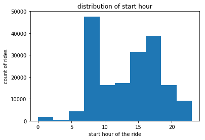

```python
# distribution of start hour

plt.hist(data= rides, x ='start_hour')
plt.xlabel('start hour of the ride')
plt.ylabel('count of rides')
plt.title('distribution of start hour')
;
```

#### 2. What is the distribution of customer type?

```
''
```

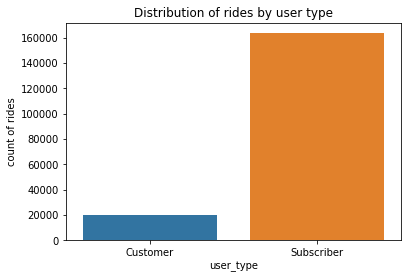

```python
# use a bar plot because usertype is categorical to understand the distribution
sb.countplot(data= rides, x = 'user_type')
plt.ylabel('count of rides')
plt.title('Distribution of rides by user type')
;
```

From the plot above, subscriber user_type take the most rides compared to non subscribers. This could mean that subscribers find the bike service more convienient and likely to take rides

#### 3. what is the gender distribution for the sexes in the data?

```
''
```

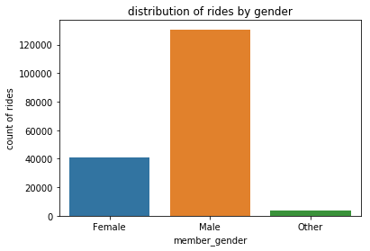

```python
# use a bar plot because gender is categorical to understand the distribution
sb.countplot(data= rides, x = 'member_gender')
plt.ylabel('count of rides')
plt.title('distribution of rides by gender')
;
```

Males are more likely to take rides than the other genders in the dataset.

#### 4. How does the day of the week affect rides?

```
''
```

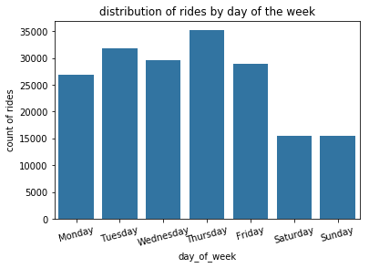

```python
# distribution by days of the week
sb.countplot(data= rides, x= 'day_of_week', color= base_color)
plt.xticks(rotation = 15)
plt.ylabel('count of rides')
plt.title('distribution of rides by day of the week')
;
```

Thursdays had the most rides taken in February 2019, with Tuesday coming in second. The days with the least rides was Saturday and Sunday which might mean that people take less rides on the weekends

#### 5. How long are rides taking in minutes?

```
''
```

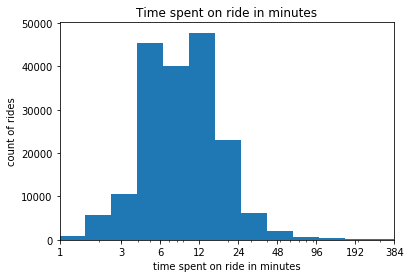

```python
# distribution of rides by time taken
bins = 10 ** np.arange(0,3.2+ 0.2, 0.2)
ticks = [1, 3, 6, 12, 24, 48, 96, 192,384,1068 ]
plt.hist(data= rides, x = 'duration_min', bins= bins)
plt.xscale('log')
plt.xticks(ticks, ticks)
plt.xlabel('time spent on ride in minutes')
plt.ylabel('count of rides')
plt.xlim(1, 384)
plt.title('Time spent on ride in minutes')
;
```

```
''
```

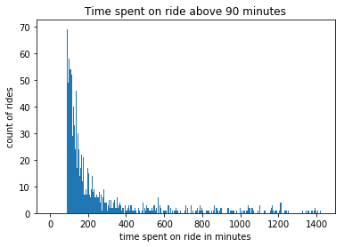

```python
# look at the distribution and frequency for long trips above 1.5 hour
long_trips = rides[rides['duration_min'] > 90]
bins = np.arange(0, long_trips['duration_min'].max() +5, 5)
plt.hist(data= long_trips, x= 'duration_min', bins= bins)
plt.xlabel('time spent on ride in minutes')
plt.ylabel('count of rides')
plt.title('Time spent on ride above 90 minutes')
;
```

The distribution of the duration in minutes feature is bimodal with one peak between 4 minutes and 6 minutes and the other between 11 minutes and 14 minutes. The trips are usually short distance except for outliers. The longest time was 1424 which is approximately 23 hours and a very long time for a ride and quite a number of trips were longer than an hour and a half. It would be interesting to dive deeper into this variable in the bivariate plots and see how it's affected when combined with other variables.

#### 6. What is the age distribution for riders as at the date of the ride?

```
''
```

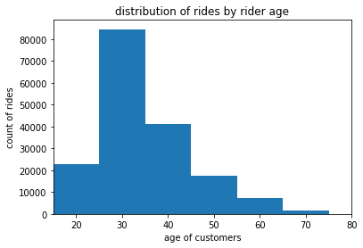

```python
# remove customers that didn't provide a birth date before plotting
age_df = rides[rides['member_age_at_ride_date'] < 2019]

bins = np.arange(15, age_df['member_age_at_ride_date'].max()+10, 10)
plt.hist(data= age_df, x= 'member_age_at_ride_date', bins = bins)
plt.xlabel('age of customers')
plt.ylabel('count of rides')
plt.xlim(15, 80)
plt.title('distribution of rides by rider age')
;
```

The customer age is right skewed with customers taking the most trips aged between mid 20s and late 30s.

### Discuss the distribution(s) of your variable(s) of interest. Were there any unusual points? Did you need to perform any transformations?

> I had to extract the start time of the ride from the start_time column and created a new column called start_hour. The start_hour had small range values so no transformation was needed. It has a bimodal distribution with the first peak between 7am and 9am and the second peak between 4pm and 6pm .

### Of the features you investigated, were there any unusual distributions? Did you perform any operations on the data to tidy, adjust, or change the form of the data? If so, why did you do this?

> While working with age, I ignored all customers that didn't provide a date_of_birth thereby looking at a distribution of only customers that provided a date of birth because that would provide a good understanding of the age disntribution. Date of birth was calculated as of the year the ride was taken. Also while looking at the time spent on the ride, some customers had trips longer than an hour with highest customer lasting 23 hours on the ride.

## Bivariate Exploration

> In this section, I investigate relationships between pairs of variables in the data.

#### 7. What relationship exists between start_hour of ride and duration_min?

```
''
```

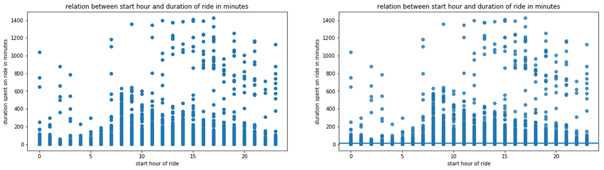

```python
# relationship between start hour and how long aride can take
plt.figure(figsize= [20, 5])

# # plot one
plt.subplot(1,2,1)
plt.scatter(data= rides, x = 'start_hour', y= 'duration_min')
plt.xlabel('start hour of ride')
plt.ylabel('duration spent on ride in minutes')
plt.title('relation between start hour and duration of ride in minutes')
;

# plot 2
plt.subplot(1,2,2)
sb.regplot(data= rides, x = 'start_hour', y= 'duration_min')
plt.xlabel('start hour of ride')
plt.ylabel('duration spent on ride in minutes')
plt.title('relation between start hour and duration of ride in minutes')
;
```

There seems to be no correlation between start time of the trip and how long it the trip takes. From the dataset, it seems trip duration is evenly distributed across different hours of the day

#### 8. What relationship does day of the week and start hour of trip have?

```
''
```

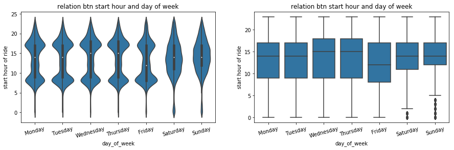

```python
# plot relationship between start hour and day of week
plt.figure(figsize= [15,4])

# first plot a violin plot
plt.subplot(1,2,1)
sb.violinplot(data= rides, x = 'day_of_week', y= 'start_hour', color= base_color)
plt.xticks(rotation = 15)
plt.ylabel('start hour of ride')
plt.title('relation btn start hour and day of week')
;
# second, plot a box plot to get clear picture
plt.subplot(1,2,2)
sb.boxplot(data= rides, x = 'day_of_week', y= 'start_hour', color= base_color)
plt.xticks(rotation = 15)
plt.ylabel('start hour of ride')
plt.title('relation btn start hour and day of week')

;
```

#### 9. How is the start hour of the trip distributed across the different genders?

```
''
```

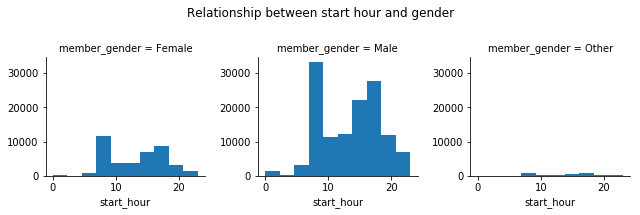

```python
# plot relationship between start hour and gender
h = sb.FacetGrid(data= rides, col = 'member_gender', sharex= True, sharey = True, margin_titles= True)
h.map(plt.hist,'start_hour')
h.fig.subplots_adjust(top=0.75)
h.fig.suptitle('Relationship between start hour and gender')
;
```

```
''
```

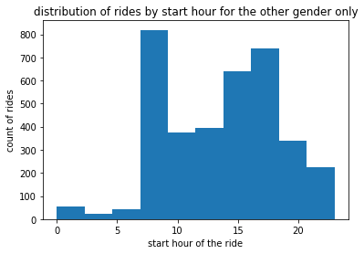

```python
other_df = rides[rides['member_gender'] == 'Other']
plt.hist(data= other_df, x = 'start_hour')
plt.xlabel('start hour of the ride')
plt.ylabel('count of rides')
plt.title('distribution of rides by start hour for the other gender only')
;
```

The female and male sexes exhibit the same trend as that of the entire dataset, which is a bimodal distribution. For the 'other' sex, because of the few observations in the dataset, I plotted out a different plot for it on a different scale and it shows the same pattern as the other sexes.

#### 10. What is the relationship between age and gender?

```
''
```

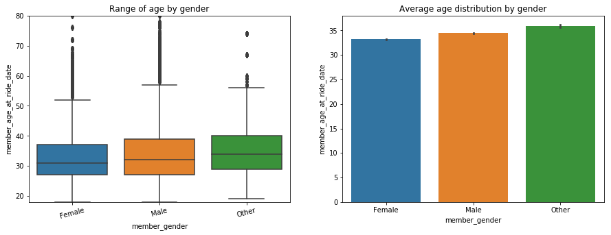

```python
# only consider data for customers that shared a date of birth
plt.figure(figsize= [15, 5])

# boxplot for age distribution
plt.subplot(1,2,1)
sb.boxplot(data= age_df, x = 'member_gender', y = 'member_age_at_ride_date')
plt.xticks(rotation = 15)
plt.ylim(18, 80)
plt.title('Range of age by gender')
;

# barplot
plt.subplot(1,2,2)
sb.barplot(data= age_df, x = 'member_gender', y = 'member_age_at_ride_date')
plt.title('Average age distribution by gender')
;
```

#### 11. Does the rider's gender affect how long the ride will last?

```
''
```

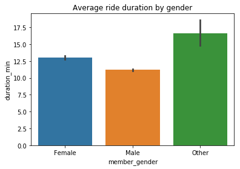

```python
# plot barplot
sb.barplot(data= rides, x = 'member_gender', y = 'duration_min')
plt.title('Average ride duration by gender')
;
```

#### 12. Does the customer type affect the time spent on the ride?

```
''
```

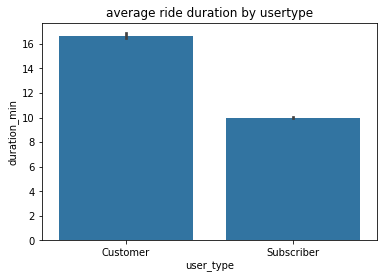

```python
# how duration and user type are related
short_df = rides[rides['duration_min'] <= 100]
sb.barplot(data= short_df, x = 'user_type', y= 'duration_min', color= base_color)
plt.title('average ride duration by usertype')
;
```

Customers seem to take on average longer trips than subscribers with and average of 17 minutes compared to subscribers who take on average 10 minutes

## Multivariate Exploration

> Creating plots of three or more variables to investigate the data even further.

In this part of the analysis, I would like to concentrate on how day of week, gender and user type interact with the main variable

#### 13. How does day_of_week, start_hour and usertype affect the ride patterns?

```
''
```

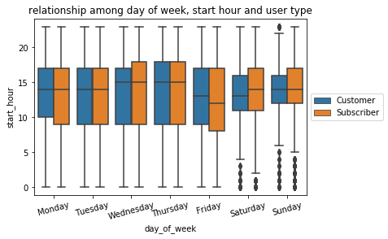

```python
# distribution relationship of user type, day of week and start hour
sb.boxplot(data= rides, x = 'day_of_week', y ='start_hour', hue= 'user_type')
plt.legend(loc = 6, bbox_to_anchor = (1.0, 0.5))
plt.xticks(rotation = 15)
plt.title('relationship among day of week, start hour and user type')
;
```

#### 14. What specific hotspots exist among between day_of_week and gender, in terms of average minutes taken on the ride?

```
''
```

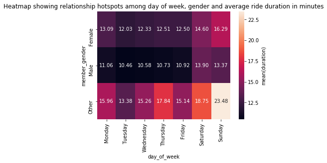

```python
# heatmap of relationship between day of week, gender and duration in minutes
hour_mean = rides.groupby(['day_of_week', 'member_gender']).mean()['duration_min']
hour_mean = hour_mean.reset_index(name = 'duration_avg')
hour_mean = hour_mean.pivot(index = 'member_gender', columns='day_of_week',
                           values= 'duration_avg')
sb.heatmap(hour_mean, annot= True, fmt = '.2f', cbar_kws= {'label': 'mean(duration)'})
plt.title('Heatmap showing relationship hotspots among day of week, gender and average ride duration in minutes')
;
```

#### 15. How does day of week, gender affect rides in terms of the average start hour of the ride?

```
Text(0.5,1,'Relationship hotspots for day of week, gender and average start hour')
```

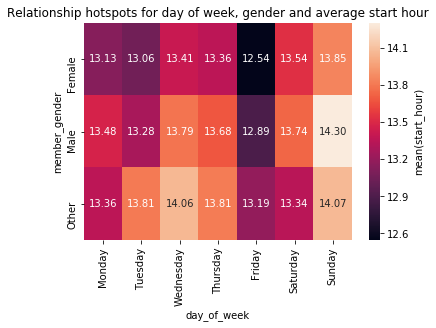

```python
#heatmap of relationship between day of week, gender and start hour
hour_mean = rides.groupby(['day_of_week', 'member_gender']).mean()['start_hour']
hour_mean = hour_mean.reset_index(name = 'start_hour_avg')
hour_mean = hour_mean.pivot(index = 'member_gender', columns='day_of_week',
                           values= 'start_hour_avg')
sb.heatmap(hour_mean, annot= True, fmt = '.2f', cbar_kws= {'label': 'mean(start_hour)'});

plt.title('Relationship hotspots for day of week, gender and average start hour')
```

Generally, trips start at 1pm all week long across the different genders except for Fridays where males and females start slightly earlier at midday. All sexes take later trips on Sundays.

#### 16. Does user type and gender affect the average trip duration?

```
''
```

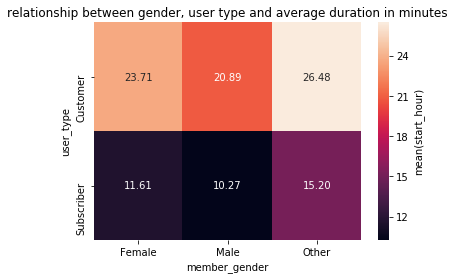

```python
# avg trip duration by gender and usertype
hour_mean = rides.groupby(['member_gender', 'user_type']).mean()['duration_min']
hour_mean = hour_mean.reset_index(name = 'duration_avg')
hour_mean = hour_mean.pivot(index = 'user_type', columns='member_gender',
                           values= 'duration_avg')
sb.heatmap(hour_mean, annot= True, fmt = '.2f', cbar_kws= {'label': 'mean(start_hour)'})
plt.title('relationship between gender, user type and average duration in minutes')
;
```

Customers from the other gender category had the longest trips as expected and customer usertype generally has a higher duration across all genders.

### Talk about some of the relationships you observed in this part of the investigation. Were there features that strengthened each other in terms of looking at your feature(s) of interest?

> The relationship between duration, gender and day of week was strong, the trend across sexes and days of the week was consistent across all variables. It was clear, even though the interactions were different for each sex, that there was a pattern between trip duration, gender and the day of the week, males took shorter trips, females took slightly longer trips and the other gender was even longer.

### Were there any interesting or surprising interactions between features?

> The user types had a similar pattern for both the customer and subscriber type. The patterns across days of the week for the start hour of the trip had the same pattern for both user types for the most part of the days. This was surprising because my assumption was that subscribers would have a different trip pattern because they tend to be super users.